# R map

Sanghoo Yoon

# 지리정보 그래프

## maps 패키지

- 전 세계 나라의 경계선이 입력된 지도 자료이다.
- 나라의 주별 경계선까지 입력되어 있으나 지도가 1990년 자료를 기준으로 개발되어 업데이트 된 나라와 업데이트 안된 나라가 섞여있다.
- col과 fill을 통해 나라별 특징을 시각화 하기 좋다.
- 미국의 경우 state 까지 세분화 하여 시각화가 가능하다.

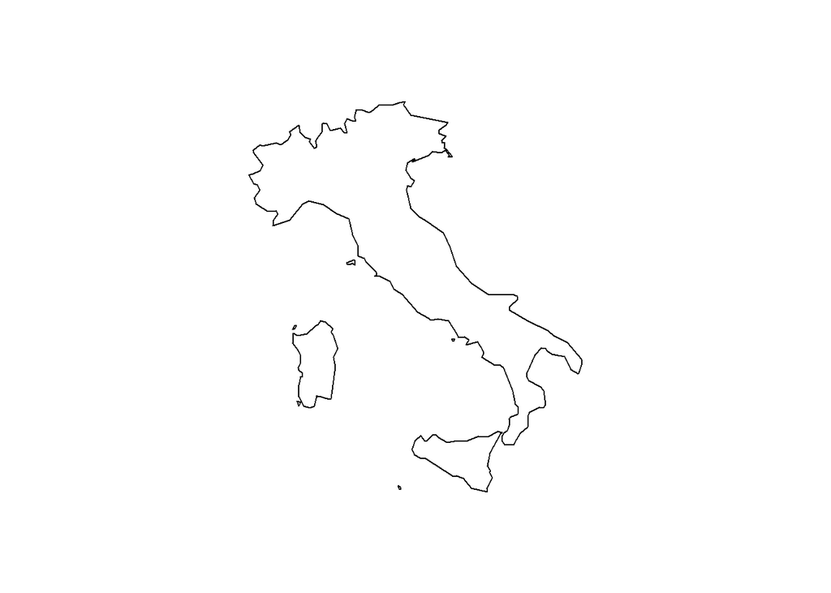

```r
if(!require(ggplot2)) install.packages("ggplot2")
if(!require(maps)) install.packages("maps")
library(ggplot2)
library(maps)

map("world","italy")
```

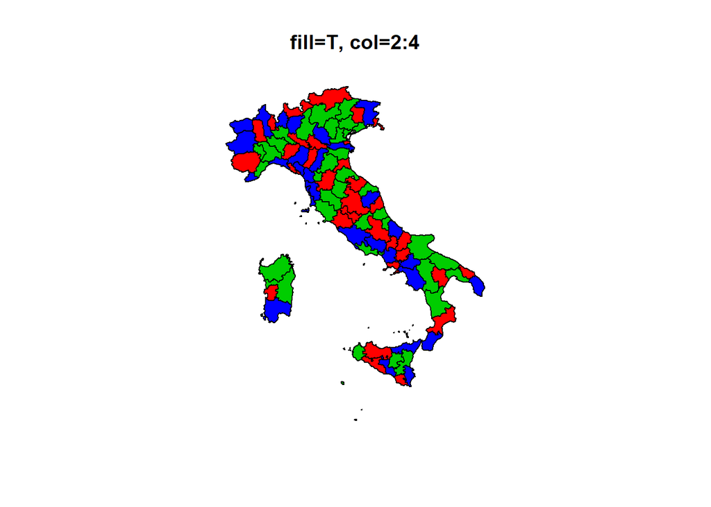

```r
map("italy", fill=TRUE, col=2:4)
title("fill=T, col=2:4")
```

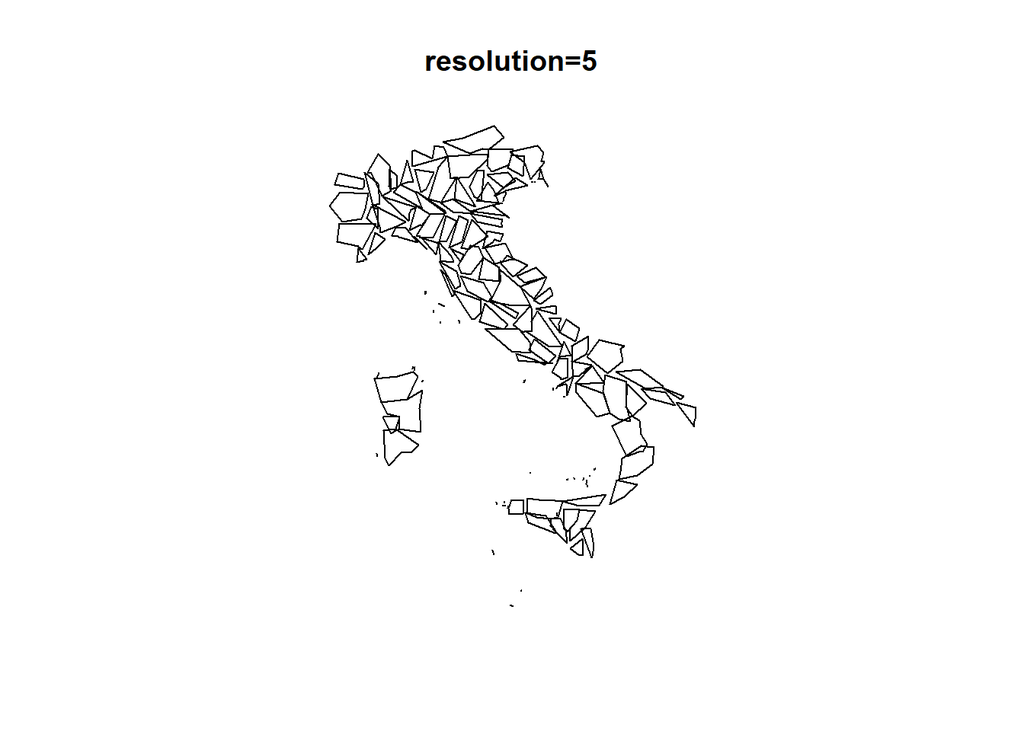

```r
# 지역별로 색상을 입력할 경우 지역별 통계를 시각화 할 수 있다.
# 이경우 cut 함수를 사용하면 좋다.

map("italy", resolution=5)
title("resolution=5")
```

```r
italy <- map_data("world","italy")
head(italy, 20)
```

```
##        long      lat group order region            subregion
## 1  12.05127 36.75703     1     1  Italy Isola di Pantelleria
## 2  12.00332 36.74600     1     2  Italy Isola di Pantelleria
## 3  11.94062 36.78037     1     3  Italy Isola di Pantelleria
## 4  11.93643 36.82861     1     4  Italy Isola di Pantelleria
## 5  11.94805 36.84307     1     5  Italy Isola di Pantelleria
## 6  12.02422 36.82095     1     6  Italy Isola di Pantelleria
## 7  12.04805 36.77637     1     7  Italy Isola di Pantelleria
## 8  12.05127 36.75703     1     8  Italy Isola di Pantelleria
## 10 15.57656 38.22031     2    10  Italy               Sicily
## 11 15.50889 38.10664     2    11  Italy               Sicily
## 12 15.47568 38.06294     2    12  Italy               Sicily
## 13 15.23447 37.78481     2    13  Italy               Sicily
## 14 15.20684 37.72056     2    14  Italy               Sicily
## 15 15.18984 37.65073     2    15  Italy               Sicily
## 16 15.16484 37.58955     2    16  Italy               Sicily
## 17 15.13105 37.53189     2    17  Italy               Sicily
## 18 15.09951 37.45860     2    18  Italy               Sicily
## 19 15.10566 37.37549     2    19  Italy               Sicily
## 20 15.11699 37.33472     2    20  Italy               Sicily
## 21 15.14600 37.30801     2    21  Italy               Sicily
```

```r
unique(italy$subregion)
```

```
## [1] "Isola di Pantelleria" "Sicily"               "Sant'Antonio"
## [4] "Forio"                "Asinara"              "Sardinia"
## [7] "Isola d'Elba"         NA
```

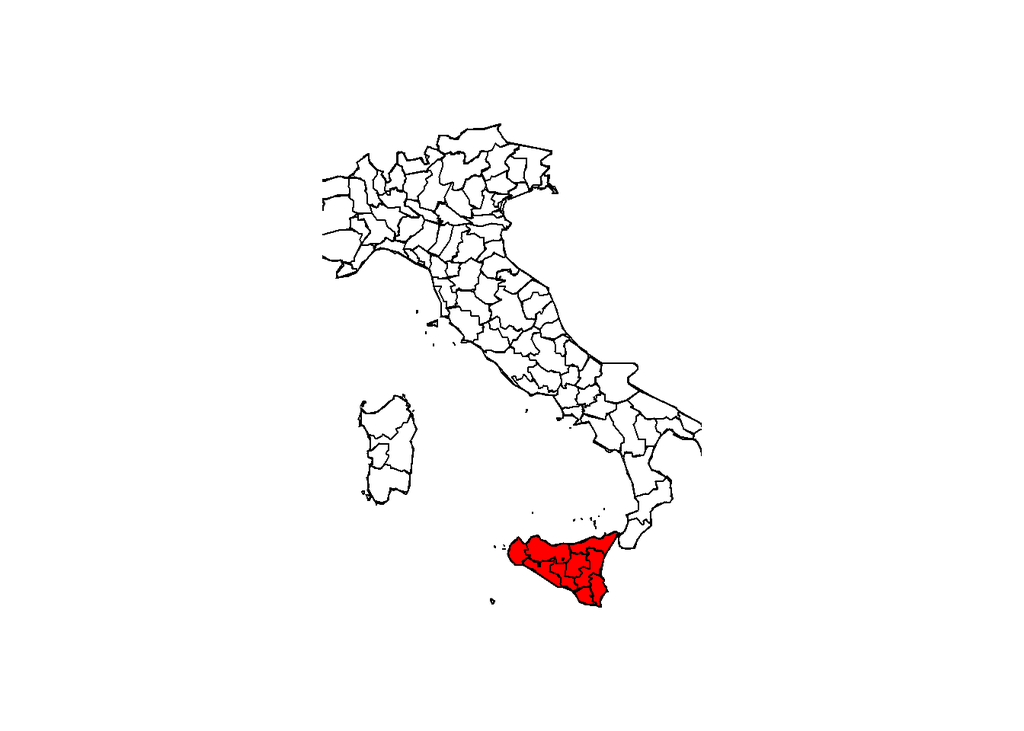

```r
map('world','italy')
sicily <- subset(italy, italy$subregion=="Sicily")
polygon(sicily$lon,sicily$lat, col="red")
map("italy", add=T)
```

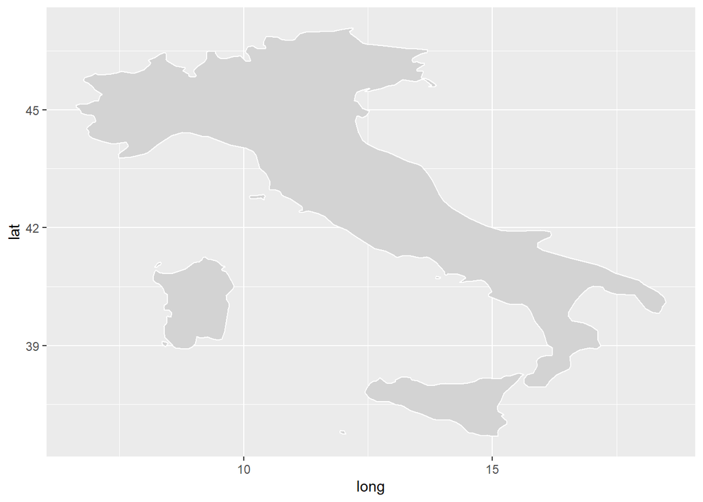

```r
ggplot(italy, aes(x = long, y = lat, group = group)) +
  geom_polygon(fill="lightgray", colour = "white")
```

```r
#한국지도 데이터 정보
korea <- map_data("world","South Korea")
unique(korea$subregion)
```

```
##  [1] "Cheju Do"  "11"        "3"         "21"        "5"         "Namhae Do"
##  [7] "Koje Do"   "8"         "Ullung Do" "10"        NA
```

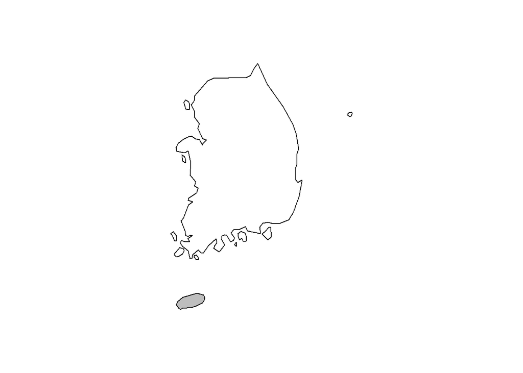

```r
#한국지도를 그리고 제주도만 회색으로 그려보자.
map('world','South Korea')
jeju <- subset(korea, korea$subregion=="Cheju Do")
polygon(jeju$lon,jeju$lat, col="grey")
```

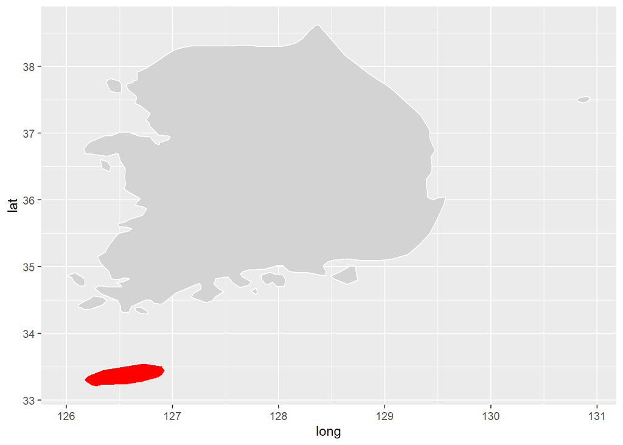

```r
ggplot(korea, aes(x = long, y = lat, group = group)) +
  geom_polygon(fill="lightgray", colour = "white")+
  geom_polygon(data=jeju, aes(x=long, y=lat), fill="red", colour = "white")
```

```r
country <- map_data("state")
head(country)
```

```
##        long      lat group order  region subregion
## 1 -87.46201 30.38968     1     1 alabama      <NA>
## 2 -87.48493 30.37249     1     2 alabama      <NA>
## 3 -87.52503 30.37249     1     3 alabama      <NA>
## 4 -87.53076 30.33239     1     4 alabama      <NA>
## 5 -87.57087 30.32665     1     5 alabama      <NA>
## 6 -87.58806 30.32665     1     6 alabama      <NA>
```

[figure not shown]

```r
NJ <- subset(country, country$region=="new jersey")

map("state")
polygon(NJ$long, NJ$lat, col="gold")
map.text("state", add=T)
```

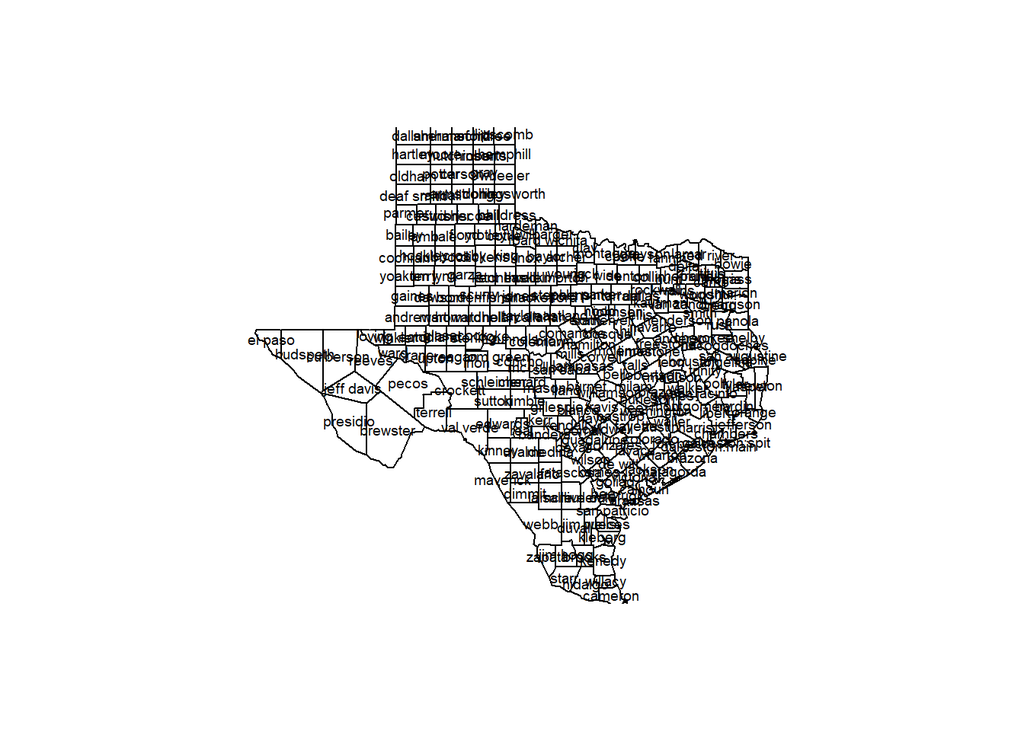

```r
map('county', 'texas')
map.text('county', 'texas',add=T, cex=0.6)
```

map에 있는 자료만 가지고는 경상북도, 대구광역시에 해당하는 통계를 시각화 하는데 어려움이 있다.

이유 : 지도정보가 제대로 구축되지 있지 않음.

raster 패키지의 getData를 통해 최근자료를 다운 받아서 활용하자.

```r
if (!require(raster)) {
  install.packages("raster",repos = "http://cran.us.r-project.org")
}
```

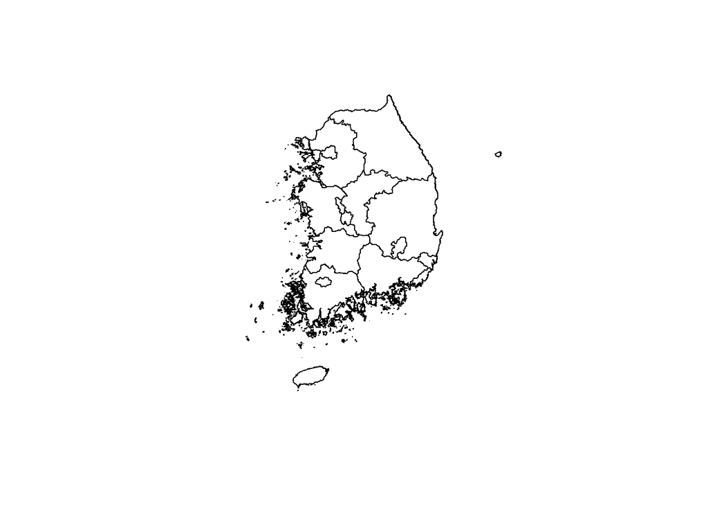

```r
library(raster)
korea1 <- getData('GADM', country='KOR', level=1)
korea2 <- getData('GADM', country='KOR', level=2)

plot(korea1)
```

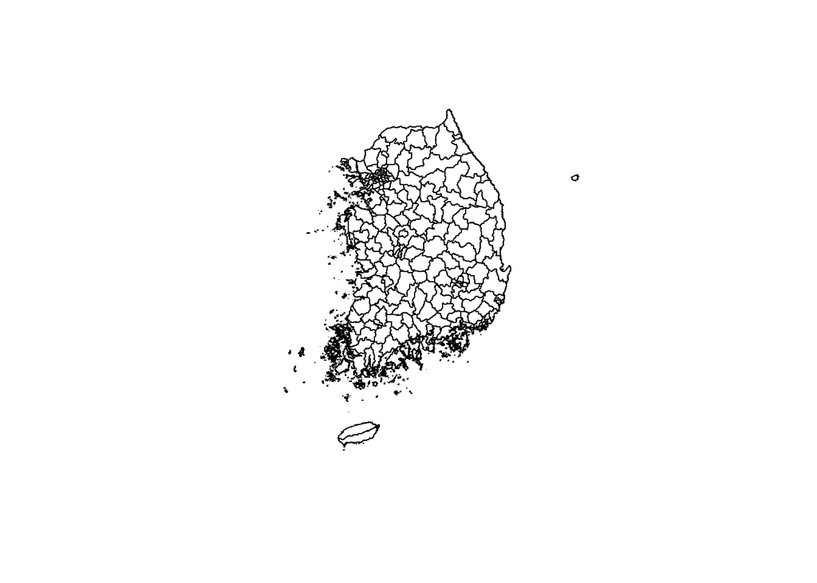

```r
plot(korea2)
```

```r
class(korea1)
```

```
## [1] "SpatialPolygonsDataFrame"
## attr(,"package")
## [1] "sp"
```

```r
korea1@data
```

```
##    GID_0      NAME_0    GID_1            NAME_1
## 1    KOR South Korea  KOR.1_1             Busan
## 10   KOR South Korea  KOR.2_1 Chungcheongbuk-do
## 11   KOR South Korea  KOR.3_1 Chungcheongnam-do
## 12   KOR South Korea  KOR.4_1             Daegu
## 13   KOR South Korea  KOR.5_1           Daejeon
## 14   KOR South Korea  KOR.6_1        Gangwon-do
## 15   KOR South Korea  KOR.7_1           Gwangju
## 16   KOR South Korea  KOR.8_1       Gyeonggi-do
## 17   KOR South Korea  KOR.9_1  Gyeongsangbuk-do
## 2    KOR South Korea KOR.10_1  Gyeongsangnam-do
## 3    KOR South Korea KOR.11_1           Incheon
## 4    KOR South Korea KOR.12_1              Jeju
## 5    KOR South Korea KOR.13_1      Jeollabuk-do
## 6    KOR South Korea KOR.14_1      Jeollanam-do
```

[output cut: 57 more lines]

### Q1. 경상북도와 대구광역시를 색칠해보자.

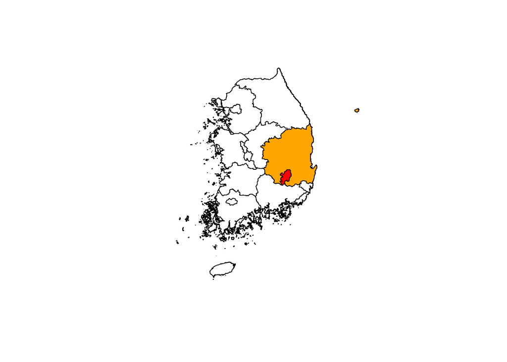

```r
korea1@data$col=NA
korea1@data[korea1@data$NAME_1=="Daegu","col"]="red"
korea1@data[korea1@data$NAME_1=="Gyeongsangbuk-do","col"]="orange"

plot(korea1, col=korea1@data$col)
```

## 여러나라의 시각화

map함수에서 c()함수를 활용하여 여러나라를 선택 후 col을 통해 표현할 있다.

maps 패키지에는 map.cities함수가 있어 나라별 수도와 인구수를 시각화 할 수 있으나

작성된 연도가 현재와 차이가 있으므로 사용을 지양하자.

추가로 map.scale, map.axes 함수가 있다.

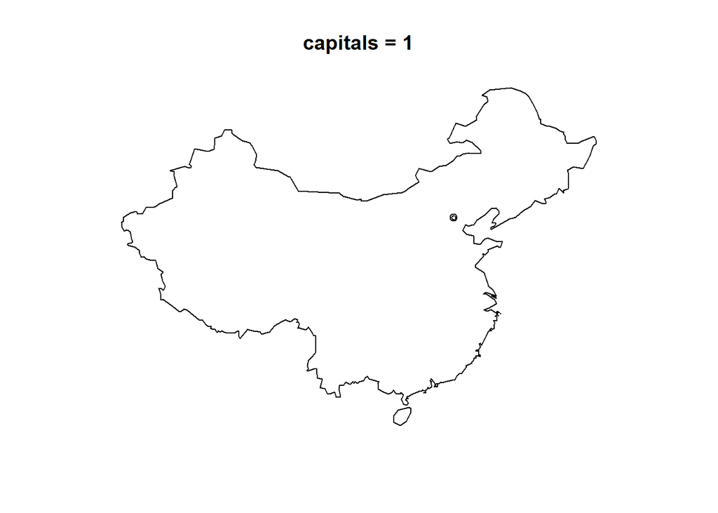

```r
map("world", "China")
map.cities(country = "China", capitals = 1)
title("capitals = 1")
```

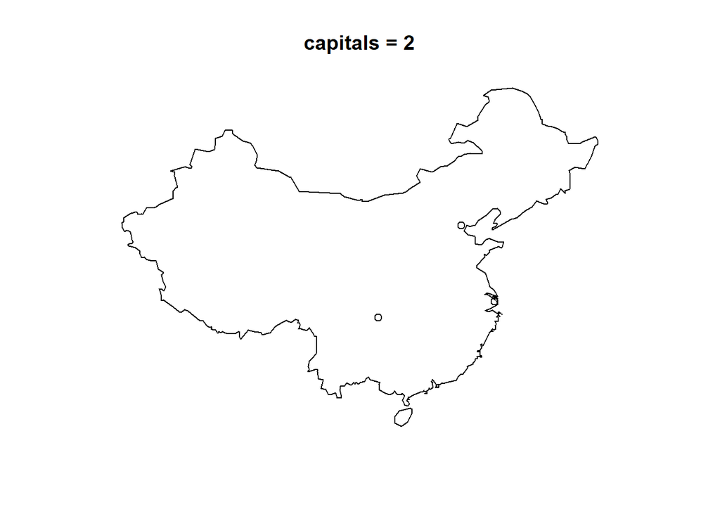

```r
map("world", "China")
map.cities(country = "China", capitals = 2)
title("capitals = 2")
```

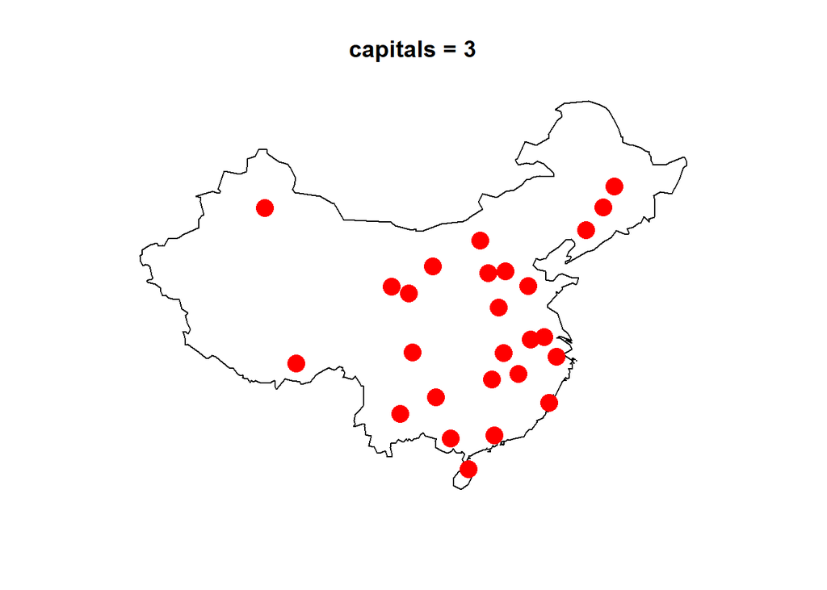

```r
map("world", "China")
map.cities(country = "China", capitals = 3, pch=16, col="red", cex=2)
title("capitals = 3")
```

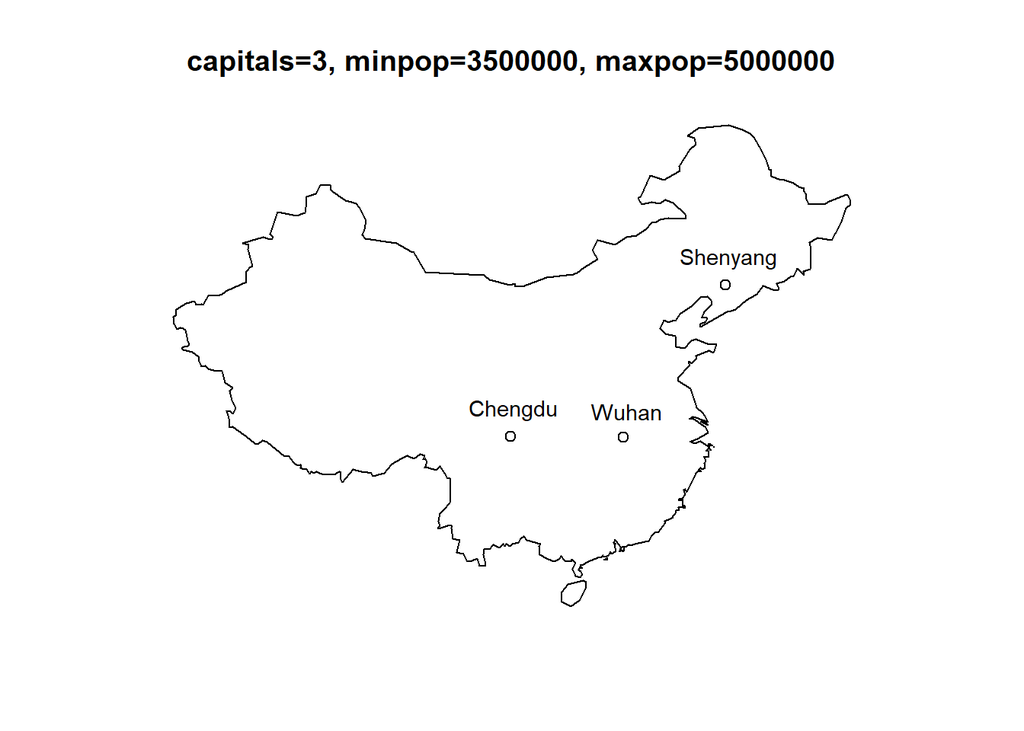

```r
map("world", "China")
map.cities(country = "China", capitals = 3, minpop = 3500000, maxpop = 5000000)
title("capitals=3, minpop=3500000, maxpop=5000000")
```

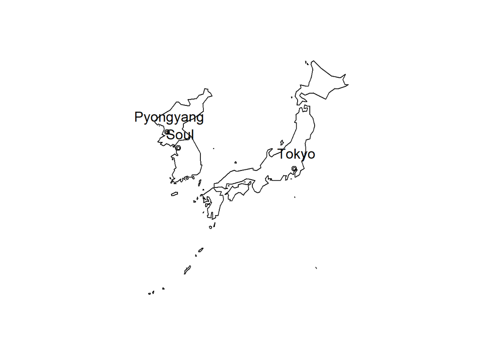

```r
map('world',c('South Korea','North Korea','Japan'))
map.cities(capitals=1)
```

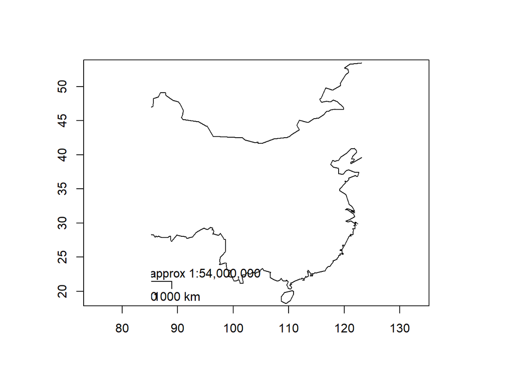

```r
map("world", "China")
map.scale()
map.axes()
```

USArrests : 미국 범죄데이터

위의 데이터를 지도로 시각화하여 위험한 지역을 지도로 나타내보자.

본토와 떨어진 하와이와 알라스카는 제외하여 시각화해보자.

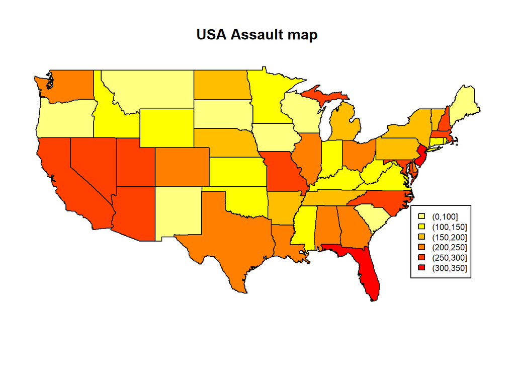

```r
# 본토에서 떨어진 Alaska, Hawaii 데이터 제외
sub.usa <- subset(USArrests,!rownames(USArrests) %in% c("Alaska", "Hawaii"))
# 주이름, 폭행범 수를 갖는 데이터 프레임 생성
usa.data <- data.frame(states = rownames(sub.usa), Assault = sub.usa$Assault)

# 범례 데이터 생성
col.level <- cut(sub.usa[, 2], c(0, 100, 150, 200, 250, 300, 350))
legends <- levels(col.level)

# 주이름, 폭행범 수, 색상을 갖는 데이터 프레임 생성
levels(col.level) <- sort(heat.colors(6), decreasing = TRUE)
usa.data <- data.frame(usa.data, col.level = col.level)

# Map 데이터 시각화
map('state', region = usa.data$states, fill = TRUE, col = as.character(usa.data$col.level))
title("USA Assault map")
legend(-76, 35, legends, fill = sort(heat.colors(6), decreasing = TRUE), cex = 0.7)
```

```r
if (!require(mapproj)) install.packages('mapproj',repos = "http://cran.us.r-project.org")
library(mapproj)
data(unemp)
data(county.fips)

head(unemp)
```

```
##   fips   pop unemp
## 1 1001 23288   9.7
## 2 1003 81706   9.1
## 3 1005  9703  13.4
## 4 1007  8475  12.1
## 5 1009 25306   9.9
## 6 1011  3527  16.4
```

```r
head(county.fips)
```

```
##   fips        polyname
## 1 1001 alabama,autauga
## 2 1003 alabama,baldwin
## 3 1005 alabama,barbour
## 4 1007    alabama,bibb
## 5 1009  alabama,blount
## 6 1011 alabama,bullock
```

```r
# define color buckets
colors = c("#F1EEF6", "#D4B9DA", "#C994C7", "#DF65B0", "#DD1C77", "#980043")
unemp$colorBuckets <- as.numeric(cut(unemp$unemp, c(0, 2, 4, 6, 8, 10, 100)))
leg.txt <- c("<2%", "2-4%", "4-6%", "6-8%", "8-10%", ">10%")

newdata <- merge(county.fips, unemp, by="fips")
head(newdata)
```

```
##   fips        polyname   pop unemp colorBuckets
## 1 1001 alabama,autauga 23288   9.7            5
## 2 1003 alabama,baldwin 81706   9.1            5
## 3 1005 alabama,barbour  9703  13.4            6
## 4 1007    alabama,bibb  8475  12.1            6
## 5 1009  alabama,blount 25306   9.9            5
## 6 1011 alabama,bullock  3527  16.4            6
```

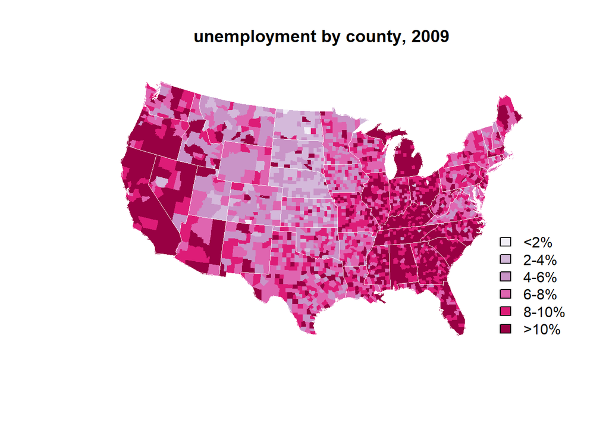

```r
# draw map
map("county", col = colors[newdata$colorBuckets], fill = TRUE, resolution = 0, lty = 0, projection = "polyconic")
map("state", col = "white", fill = FALSE, add = TRUE, lty = 1, lwd = 0.7, projection="polyconic")
title("unemployment by county, 2009")
legend("bottomright", leg.txt, fill = colors, bty = 'n')
```

# 풀어보기

2017년 행정구역별 1인당 지역 내 총생산은 아래 사이트와 같다.

raster에서 시도별 지도를 다운 받아 1인당 지역 총소득을 시각하세요.

단, 세종시는 대전광역시와 지역총소득이 같다고 가정하자.

색 : heat.color를 이용

구분 : 1인당 지역총소득

http://kosis.kr/statHtml/statHtml.do?orgId=101&tblId=DT_1C65